# explanatory_analysis slides

### Analyzing Ford GoBike data.

Ford GoBike is a regional public bicycle sharing system in the San Francisco Bay Area, California. Beginning operation in August 2013 as Bay Area Bike Share, The system is expected to expand to 7,000 bicycles around 540 stations in San Francisco, Oakland, Berkeley, Emeryville, and San Jose. After Motivate's acquisition by Lyft, the system was subsequently renamed to Bay Wheels in June 2019. https://www.fordgobike.com/system-data

About dataset:  
Ford Gobike system data : https://www.fordgobike.com/system-data is choosen as the source data, This dataset has information regarding the individual rides made in a bike-sharing system.Multiple data files will need to be joined together if a full year’s coverage is desired.  
The company has seen an acquisition by mid of 2019, so we will be exploring the Ford GoBike data for the year 2019, to gain some insights from several observation.

### Major questions to be answered?

1. Find the time period where campaigns should be started to attract more customers to subsribe to the application?
2. Proportion of the customers using application, does the subscribers prefer using application or clipper for renting bikes.
3. Analyze the surge hours during a day, so that we need to ensure that customers are met with the need.
4. Customer target: Is there a specific customer target to be generated, like tourists, whitescholors etc.
5. Is the new feature bikeshare a success, discuss the effort needed to attarct more customers to bike share plan

#### Monthly Bike rides Usage

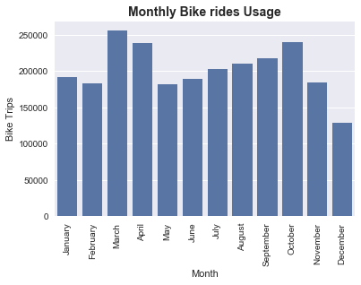

```python
# Monthly Bike rides Usage
basecolor = sns.color_palette()[0]
sns.countplot(data=data_clean, x='st_month_name', color= basecolor)
plt.xlabel("Month")
plt.ylabel("Bike Trips")
plt.title('Monthly Bike rides Usage', fontsize=14, fontweight='semibold');
plt.xticks(rotation = 90);
```

```
Month of march, april and october see a higher number of bike rides
```

#### Bike rides during Weekdays

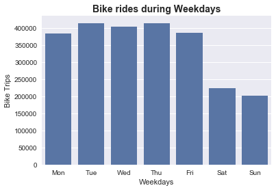

```python
# Bike rides during Weekdays
weekday = ['Mon', 'Tue', 'Wed', 'Thu', 'Fri', 'Sat', 'Sun']
basecolor = sns.color_palette()[0]
sns.countplot(data=data_clean, x='st_weekday', color = basecolor, order = weekday)
plt.xlabel("Weekdays")
plt.ylabel("Bike Trips")
plt.title('Bike rides during Weekdays', fontsize=14, fontweight='semibold');
```

```
Bike rides are mostly opted on weekdays, whereas in weekends the total rides gets halfed. Working population relying on the bike rides can be a reason.
```

#### Bike rides during a day by user-type

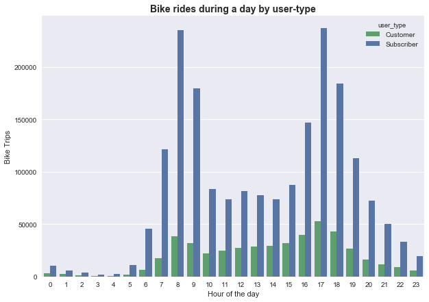

```python
# Bike rides during a day by user-type
plt.figure(figsize = (10, 7))
basecolor = sns.color_palette()[0]
palette ={"Subscriber":"C0","Customer":"C1"}
sns.countplot(data=data_clean, x='st_hour',hue = 'user_type', color = basecolor, palette=palette)
plt.xlabel("Hour of the day")
plt.ylabel("Bike Trips")
plt.title('Bike rides during a day by user-type', fontsize=14, fontweight='semibold');
```

[output not shown]

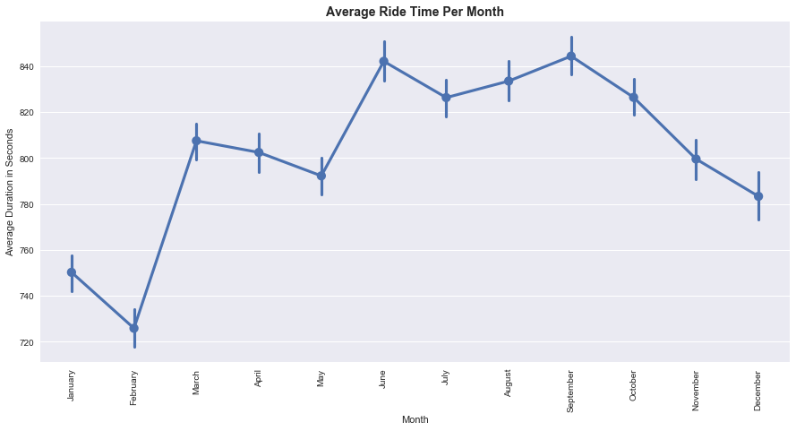

```python
#Average Ride Time per Month
#Visualizing the data in a point plot
plt.figure(figsize = (15, 7))
sns.pointplot(data = data_clean, x = 'st_month_name', y = 'duration_sec');
plt.xticks(rotation = 90);
plt.title('Average Ride Time Per Month', fontsize=14, fontweight='semibold');
plt.ylabel('Average Duration in Seconds');
plt.xlabel('Month');
plt.style.use('seaborn')
```

```
Average ride time is highest at the month of June to October, which shows during summer we have more duration in each rides
```

#### User_type based on weekday bike usage

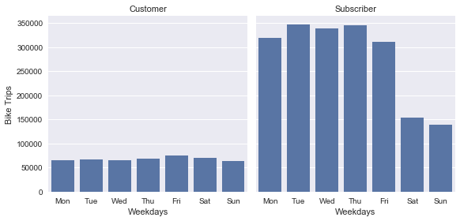

```python
# User_type based on weekday bike usage
weekday = ['Mon', 'Tue', 'Wed', 'Thu', 'Fri', 'Sat', 'Sun']
g = sns.FacetGrid(data = data_clean, col = 'user_type', size = 4 );
g.map(sns.countplot, "st_weekday", order = weekday);


g.set_titles('{col_name}')
g.set_axis_labels("Weekdays", "Bike Trips")
```

[output not shown]

#### Subscribers monthly bike rides by bike share

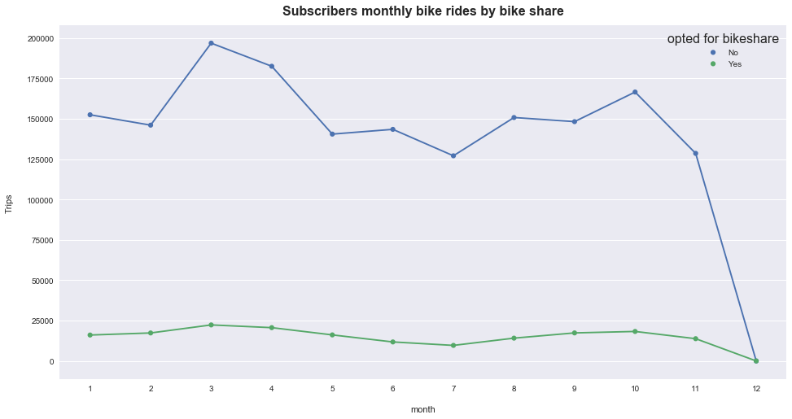

```python
plt.figure(figsize=(16,8))
ax = sns.pointplot(x='st_month', y='bike_id', hue='bike_share_for_all_trip', scale=.6, data=subscriber_data)
plt.title("Subscribers monthly bike rides by bike share", fontsize=16, y=1.015,fontweight='semibold')
plt.xlabel('month', labelpad=16)
plt.ylabel('Trips', labelpad=16)
leg = ax.legend()
leg.set_title('opted for bikeshare',prop={'size':16})
ax = plt.gca()
```

```
Company tends to obtain more subscribers during the month of march and april
```

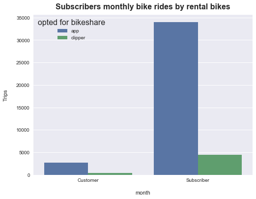

```python
#
plt.figure(figsize=(8,6))
ax = sns.barplot(x='user_type', y='bike_id', hue='rental_access_method', data=rental_data)
plt.title("Subscribers monthly bike rides by rental bikes", fontsize=16, y=1.015,fontweight='semibold')
plt.xlabel('month', labelpad=16)
plt.ylabel('Trips', labelpad=16)
leg = ax.legend()
leg.set_title('opted for bikeshare',prop={'size':16})
ax = plt.gca()
```

## Conclusion

Findings from Analysis:

'Bike rides during a day by user-type' analyze the surge hours during a day for bike usage and finds the answer for the third question, it can be seen that from 7am to 10 am and 4 pm to 7 pm we see a surge in bike usage. Comparing it to the plot 'User_type based on weekday bike usage' we could say office hours or whitescholors are our major customer target, as we could see that during weekdays we have more of the subsribers using bikes, and they can be working profesionals.

'Subscribers monthly bike rides by rental bikes', shows us subscribers prefer using application, which is good, usage of clipper is said to be low in both the type of users. 'Subscribers monthly bike rides by bike share' plot shows that most of the subscribers haven't opted for share bikes plan. So this plan needs improvement as throughout the year the users remained the same.